> We have already established that using annotated HeLa m6A sites, we can observe changes in genes with m6A sites (HL-60) cells. In order to confirm this m6A sites, we performed MeRIP-seq in treated and untreated cells, and did observe a general increase in m6A levels upon treatments for a large number of annotated sites. Here, our goal is to indpendently analyze the MeRIP data without relying on HeLa annotations and use it to define a **treatment-induced hyper-methylation sites**. We will then assess the location and behaviour of these targets across the other datasets generated in this study.

# meRIP-seq data

### Meta-gene plot

As a quality control, we confirm mRNA Methylation sites enriched in 3′ UTRs and near stop codons same as this Cell paper https://doi.org/10.1016/j.cell.2012.05.003

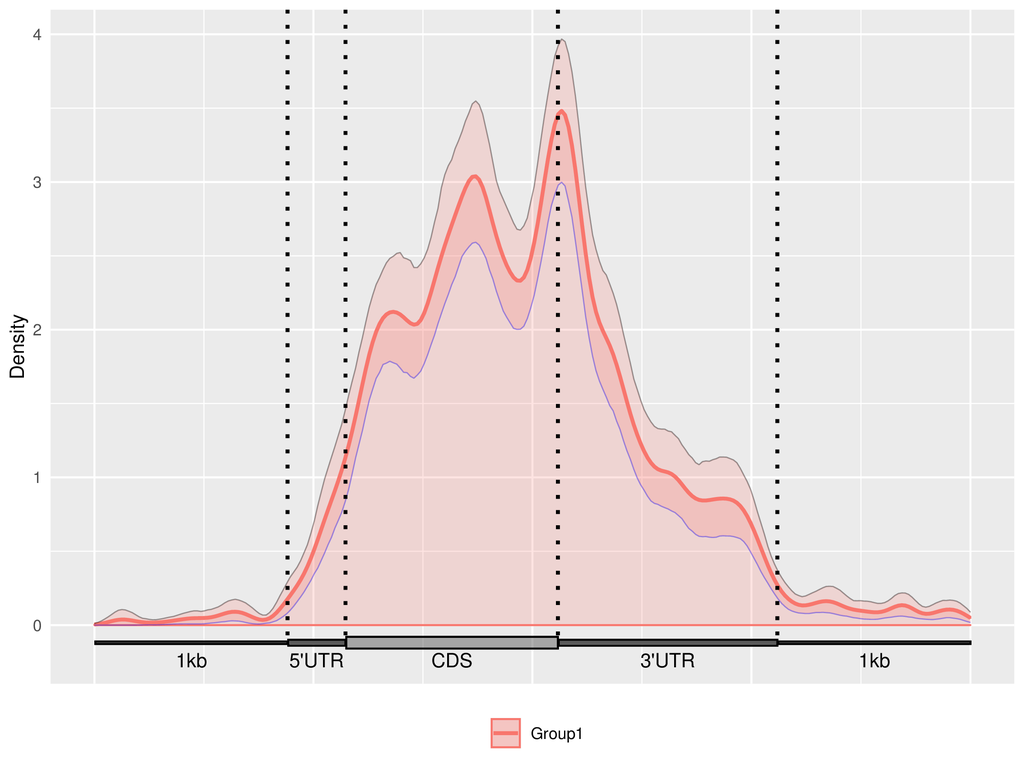

### Motif analysis

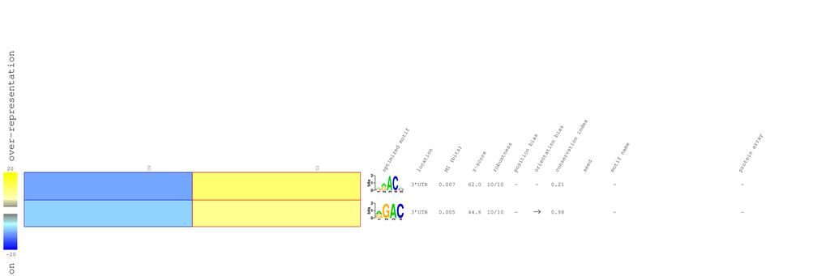

**Results from FIRE** shown above indicate that the known m6A site **DRACH** and **RGAC** (or `[AG]GAC` and `[AGT][AG]AC[ACT]` in regular expression form) is significantly enriched among the **~4700** methylations sites.

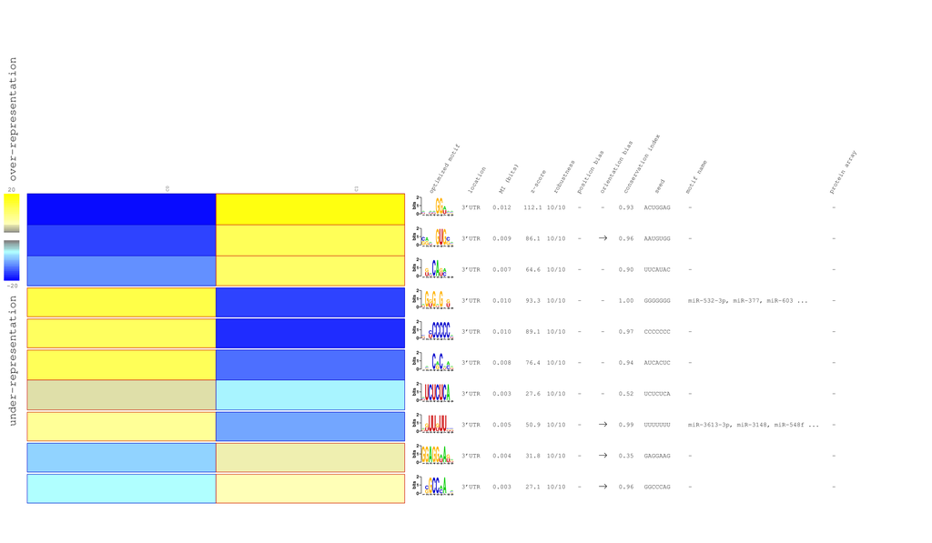

# Test enrichment of hyper/hypo-methylation sites

Here, I aim using a function from TEISER to identify the genes that are hyper or hypo methylated as genesets, and see if they have enriched accross all genes; the input table is list of genes with control vs. treated fold change of RNA expression, RNA stability and translational efficiency.

## Time series RNA-seq data

### RNA Expression

I've used `salmon` for alignment and `DESeq2` for ANNOVA like analysis (see [DESeq2 for time-series-experiments](http://bioconductor.org/packages/devel/bioc/vignettes/DESeq2/inst/doc/DESeq2.html#time-series-experiments.)). Mainly, the linear model designed as `~condition + time + condition:time` to include both time and treatment together in the model.

### hyper_mtyl_6h_DE2res

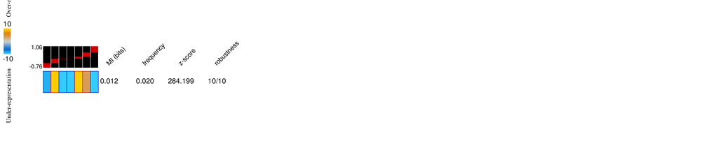

### hyper_mtyl_72h_DE2res

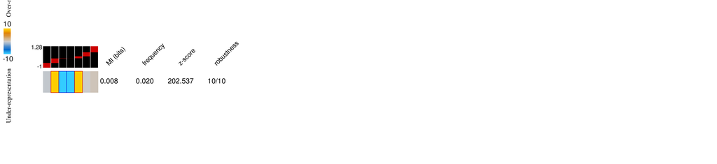

### hyper_mtyl_120h_DE2res

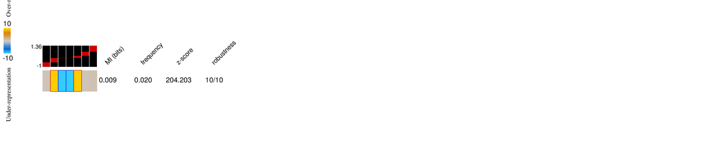

### hypo_mtyl_6h_DE2res

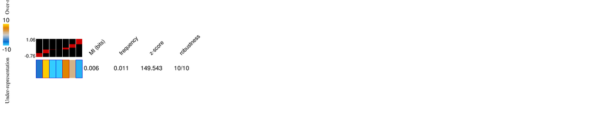

### hypo_mtyl_72h_DE2res

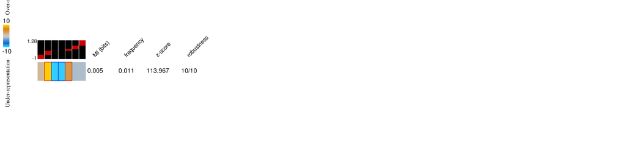

### hypo_mtyl_120h_DE2res

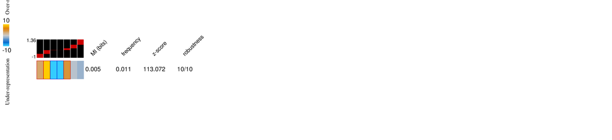

## Stability

Separately, I've used `STAR` for alignment and then, I've used `featureCount` to evalute intronic and exonic counts (similar to CRIES). Then, REMBRANDTS is the tool to estimate unbias transcript stability. Then, I use `limma` for differential analysis. Here we only check the log2FC of treated vs. control

### hyper_mtyl_6h_delta_stbl

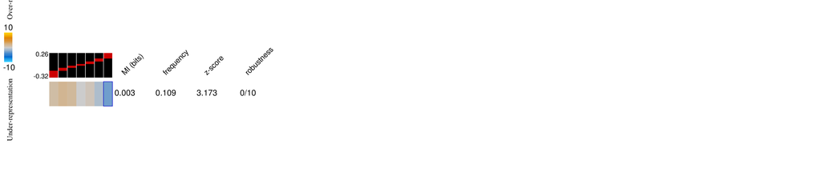

### hyper_mtyl_120h_delta_stbl

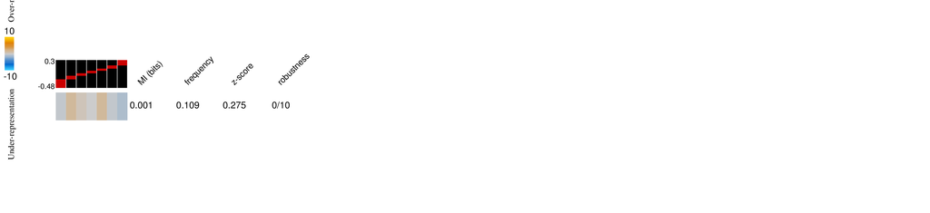

### hypo_mtyl_6h_delta_stbl

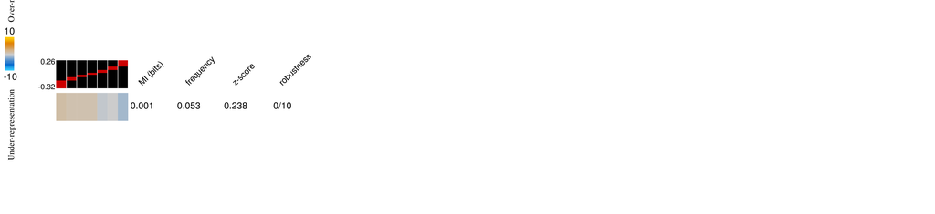

### hypo_mtyl_120h_delta_stbl

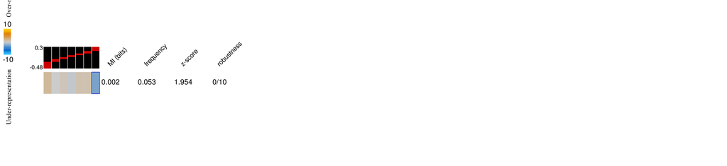

## Ribo-seq

### hyper_mtyl_lnTE_T_vs_U

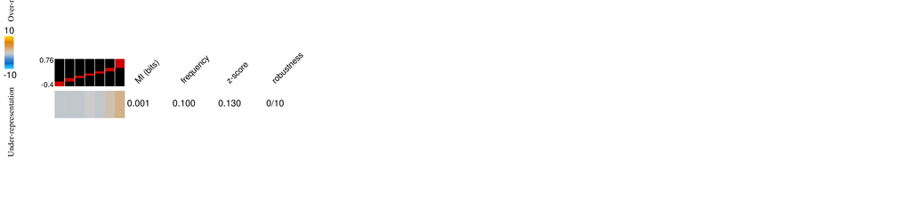

### hypo_mtyl_lnTE_T_vs_U

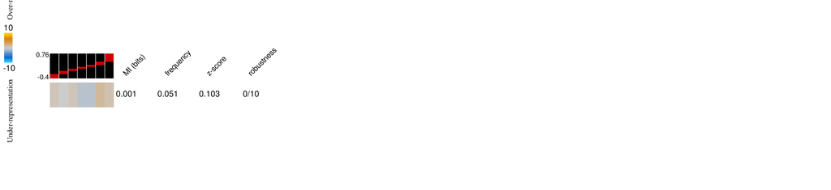

## Intersectional Analysis

```python
# %%R -i exp_target,stability_target,tm6A,hm6A -o intersection
# library(UpSetR)
# Vecs <- list(expression=unlist(exp_target), stability=unlist(stability_target), hyper.m6A=unlist(hm6A))
# intersection <- Reduce(intersect,Vecs)
# upset(fromList(Vecs), order.by = "freq")
```

[output not shown]